# Partition Tree

Conditional Density Estimation over General Outcome Spaces

Felipe Angelim

Joint work with Alessandro Leite · NeurIPS 2026

# Motivation

## Where would a regression tree put its prediction?

[figure not shown]

A CART split groups observations by $x$. Look at the **12 points in the shaded leaf**.

In classification, class frequencies give us a probability for each label.

In squared-error regression, the prediction is the leaf mean, **2.75**. What does it tell us about the gap?

## A probability space $(\Omega, \mathcal{F}, P)$

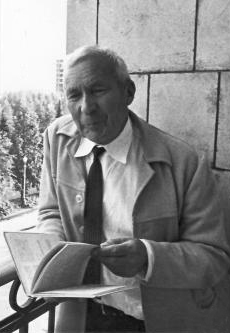

**Andrei Kolmogorov**  
[*Foundations of the Theory of Probability*, 1933](https://www.york.ac.uk/depts/maths/histstat/kolmogorov_foundations.pdf)

[figure not shown]

## One die, three levels of information

Roll a fair six-sided die. The sample space is always $\Omega=\{1,2,3,4,5,6\}$.

| What we learn | Blocks of outcomes | Measurable events |
| --- | --- | --- |
| $\mathcal F_0$ · No face information | $\Omega$ | 2 |
| $\mathcal F_1$ · Odd or even | $\{1,3,5\},\ \{2,4,6\}$ | 4 |
| $\mathcal F_2$ · Exact face | $\{1\},\ \{2\},\ \ldots,\ \{6\}$ | 64 |

Measurable events are unions of these blocks, called **atoms**. Finer atoms give $\mathcal F_0\subsetneq\mathcal F_1\subsetneq\mathcal F_2$.

Parity lets us ask if the roll was even, with probability $1/2$. The exact face lets us also ask if it was $2$, with probability $1/6$.

## From a partition to a tree

[figure not shown]

## What if we also split the outcome?

[figure not shown]

Keep the same $x$-band. Make one cut at $y=3$.

**Nine** observations fall in the top unit of height. **Three** occupy the lower three units.

Per unit of outcome space, the upper cell is **nine times as dense**.

# Partition Tree

## Measuring the mass in a rectangle

[figure not shown]

$$\widehat c(x,y)=
\begin{cases}
3/4 & (x,y)\in A_1,\\
1/12 & (x,y)\in A_2,\\
1/4 & (x,y)\in A_3.
\end{cases}$$

Take the upper-left cell $A=A_1=A_X\times A_Y$.

**Joint mass** counts points in the cell.
$$\widehat P_{XY}(A)=9/20$$

**Marginal mass** counts every point in its $x$-band.
$$\widehat P_X(A_X)=12/20$$

The cell holds $9/12$ of the band’s outcomes over a height of $\mu_Y(A_Y)=1$.

$$\widehat c_A=\frac{n_{XY}(A)}{n_X(A_X)\,\mu_Y(A_Y)}
=\frac{9}{12\cdot 1}=\frac34.$$

## Which split should the tree make?

[figure not shown]

The parent assigns density **$1/4$** throughout the band.

After the cut, the upper density is **$3/4$**. The lower density is **$1/12$**.

Score each observation by the change in its log density. For this cut,
$$\widehat G
=\frac{9\log 3+3\log(1/3)}{20}
\approx \mathbf{0.33}.$$

## Growing a Partition Tree

Try each admissible **$X$ or $Y$ split** in each current leaf. Compare the two children with their parent using the same gain.

$$\widehat G(A\to L,R)=
\sum_{B\in\{L,R\}}\frac{n_{XY}(B)}{N}
\log\frac{\widehat c_B}{\widehat c_A}$$

Split the leaf with the **largest reduction in the training log-loss surrogate**. Repeat until the split budget is spent or no admissible split remains.

Sorted thresholds need one scan per coordinate. For balanced growth, the paper gives **$O(d_Z N\log N)$** with maintained presorted indices, the same order as presorted CART.

## Scanning for an $X$-split

Sweep $x=t$ through the upper-left leaf, testing the midpoints in its $x$-band.

[figure not shown]

| Count | Left | Right |
| --- | --- | --- |
| *n*<sub>X</sub> | 0 | 12 |
| *n*<sub>XY</sub> | 0 | 9 |

Green rings mark the samples counted in *n*<sub>X</sub> on the left. Red centers mark the ones also counted in *n*<sub>XY</sub>.

Candidate

[Angelim & Leite, Appendix B.1, Algorithm 1](https://arxiv.org/pdf/2602.04042v3#page=18)

## Predicting with Partition Tree

[figure not shown]

**Given $(x,y)=(0.25,3.5)$**, follow one branch at every split. The leaf height here is $3/4$.

**Given only $x=0.25$**, follow the matching branch at each $X$-split and **both** branches at each $Y$-split.

The slice is a histogram. Its two bin areas are $3\times(1/12)=1/4$ and $1\times(3/4)=3/4$.

## A forest averages the trees’ densities

A bootstrap sample moves split boundaries. Fit a Partition Tree to each sample and average the heights at the same $(x,y)$.

$$h_F(x,y)=\frac{1}{B}\sum_{b=1}^{B}\widehat c_{A_b(x,y)}$$

For each $x$, normalize the slice so its area is one.
$$\widehat f_F(y\mid x)=
\frac{h_F(x,y)}{\int h_F(x,u)\,d\mu_Y(u)}$$

# Results

## The mean stays put as the spread changes

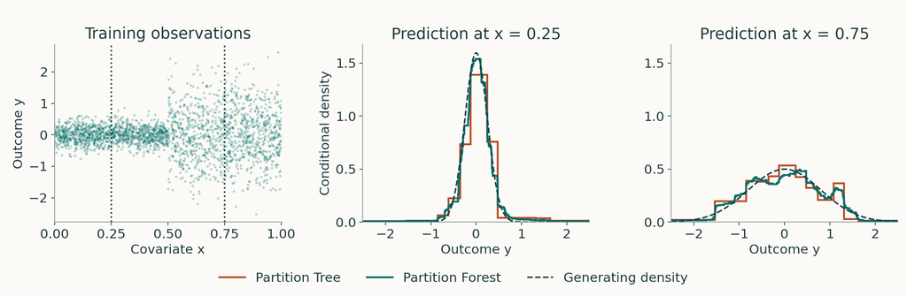

Both slices center near zero. The wider slice assigns more probability to large errors.

## Two modes can trade probability mass

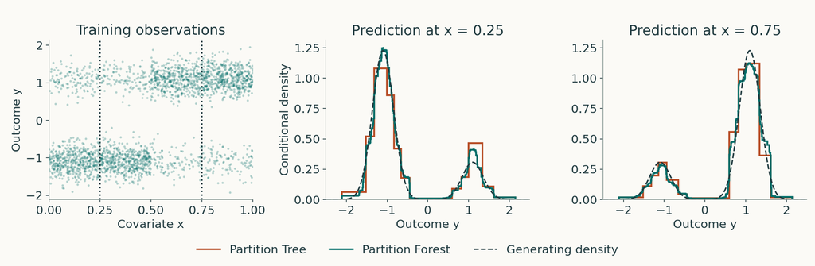

The peaks stay near $-1.1$ and $+1.1$. Moving across $x$ changes **which outcome is more likely**.

## Almost-sure $L^1$ consistency

**Theorem 3.2.** Under these conditions, the conditional density estimate converges.

$$\bigl\|\widehat f_{\pi_N}-f\bigr\|_{L^1(\nu)}\longrightarrow 0\quad\text{almost surely},\qquad \nu=P_X\otimes\mu_Y.$$

Assume i.i.d. sampling from $P_{XY}\ll\nu$, admissible leaves, finite VC dimension for leaf $X$-projections, and finite-volume outcome truncations with vanishing tail mass.

1. **Maximum leaves in one tree** $m(\mathcal A_N)=o(N)$.
2. **Maximum groupings of the same $N$ points** $\log\Delta_N^*(\mathcal A_N)=o(N)$.
3. **Mass in large leaves vanishes** as the sample grows.  
   $P_{XY}\{z\in\bar{\mathcal Z}_N:\operatorname{diam}(\pi_N[z])>\gamma_N\}\to0$ a.s. for some $\gamma_N\to0$.
4. **Maximum distinct $X$-regions in one tree** $m_X(\mathcal A_N)\sqrt{\log N/N}\to0$.

[Angelim & Leite, Theorem 3.2](https://arxiv.org/pdf/2602.04042v3#page=7)

## Classification log-loss across nine datasets

| Dataset | Partition Tree | CART | Partition Forest | Random Forest |
| --- | --- | --- | --- | --- |
| Iris | 0.46 | 0.46 | 0.50 | 0.15 |
| Breast | 0.64 | 0.70 | 0.58 | 0.56 |
| Wine | 1.02 | 1.47 | 0.86 | 0.88 |
| Digits | 0.45 | 1.48 | 0.29 | 0.29 |
| Spam | 0.22 | 0.29 | 0.17 | 0.16 |
| Support2 | 0.28 | 0.28 | 0.24 | 0.25 |
| Letter | 0.62 | 1.42 | 0.49 | 0.28 |
| Bank | 0.22 | 0.22 | 0.20 | 0.20 |
| Adult | 0.93 | 0.92 | 0.90 | 0.90 |
| **Average rank** | **1.33** | 1.67 | **1.44** | 1.56 |

Five-fold means. Lower is better. Ranks compare single trees and forests separately. [Angelim & Leite, Table 1a](https://arxiv.org/pdf/2602.04042v3#page=8)

## Regression log-loss across ten datasets

| Dataset | Partition Tree | CART | CADET | CDTree | Partition Forest | RF |
| --- | --- | --- | --- | --- | --- | --- |
| Diabetes | 5.65 | 17.93 | 5.59 | 5.58 | 5.49 | 14.21 |
| Boston | 2.90 | 8.39 | 2.89 | 2.88 | 2.53 | 4.60 |
| Energy | 2.36 | 1.67 | 10.81 | 1.55 | 2.06 | 1.55 |
| Concrete | 3.70 | 7.45 | 3.52 | 3.66 | 3.36 | 3.86 |
| Kin8nm | −0.18 | 9.42 | −0.22 | −0.18 | −0.45 | 3.30 |
| Air | 2.12 | 13.49 | 13.78 | 6.42 | 2.02 | 11.35 |
| Power | 2.87 | 3.13 | 2.90 | 2.93 | 2.60 | 2.63 |
| Naval | −4.38 | 4.69 | −4.78 | −4.29 | −4.72 | −4.98 |
| California | 0.69 | 7.07 | 0.88 | 0.58 | 0.42 | 3.11 |
| Protein | 2.22 | 12.31 | 3.13 | 2.18 | 2.10 | 6.19 |
| **Average rank** | 2.30 | 3.70 | 2.30 | **1.70** | **1.20** | 1.80 |

Five-fold means. Lower is better. CART and Random Forest (RF) use Gaussian residuals. [Angelim & Leite, Table 1b](https://arxiv.org/pdf/2602.04042v3#page=8)

CDTree led the single trees. Partition Forest beat RF on **8 of 10** datasets.

# Future Research

**Balancing Partition Forest.** Can the same rectangles give us weights that balance treatment and covariates in observational data?

[Angelim & Leite, *Balancing Partition Forest for Causal Weighting*](https://arxiv.org/abs/2611.23524v1)

**Flow Partition Tree.** Can a sequence of tree-based transformations improve probabilistic regression?

## Flow Partition Tree transports samples toward uniform

Completed rounds 0 / 8

Read up to the fitted CDF, then left to the output axis. Each output becomes the next round’s input.

## How do the models rank across metrics?

| Model | CRPS rank | CRPS wins | NLL rank | RMSE rank | PCE rank |
| --- | --- | --- | --- | --- | --- |
| FPT | **2.1** | 3 | 2.2 | 2.6 | 6.6 |
| FPT-D | 3.4 | 0 | **1.8** | 4.0 | 4.9 |
| Treeffuser | 2.3 | 4 | 5.2 | 2.9 | 3.4 |
| CatBoost | 6.3 | 0 | 4.6 | 6.1 | 5.6 |
| CatBoost-R | 3.8 | 2 | 9.4 | **2.0** | 9.0 |
| NGBoost | 5.1 | 0 | 6.9 | 4.4 | 7.6 |
| LinCDE | 7.8 | 0 | 5.9 | 7.7 | 6.4 |
| PT | 9.0 | 0 | 7.7 | 9.1 | 3.3 |
| PF | 6.9 | 0 | 5.0 | 7.4 | 7.1 |
| CTF | 8.3 | 1 | 6.3 | 8.8 | **1.1** |

*Flow Partition Trees*, Table 2. Lower mean rank is better. Wins count datasets with the lowest mean continuous ranked probability score (CRPS). FPT is tuned and FPT-D uses fixed hyperparameters. Bold marks the best score or rank. Underlining marks comparisons with the best that did not reach significance after Holm adjustment.

## Delivery time distributions

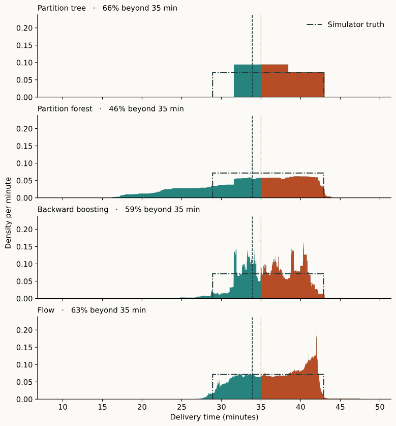